# HOMEWORK 2

Matthias Nevins

## **Thinking on Paper**

*The focus of my research is as follows*:

I will be contributing to the work of exploring functional responses in a given forest and relying on forest landscape simulation and climate envelope models as decision support tools for understanding the outcomes of different management regimes and climate projections on future forest conditions. Our study aims to examine and evaluate the long-term effects of three alternative management approaches under two projected climate scenarios within a 10,000-acre forested landscape of mixed-ownerships in southeastern Vermont, USA.

**My main research questions are:**

- 1: How does species composition change over time under two climate scenarios and three management regimes?
- 2: How does simulated future forest conditions across the six scenarios compare to the desired future condition identified for the landscape?
- 3: How do differences in landowner behavior in regards to application of adaptive measures influence landscape-level resilience to climate change?

### Path Diagram

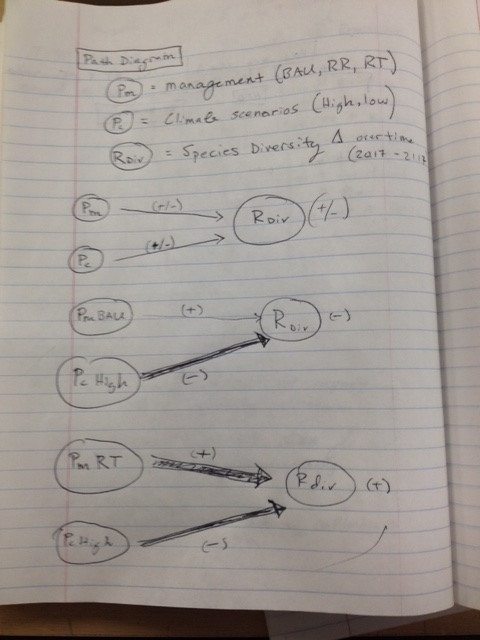

This path diagram explores the potential relationships between the response variable (R = Species diversity) and two predictor variables (Pm = Management and Pc = climate scenarios).

### Logic Tree

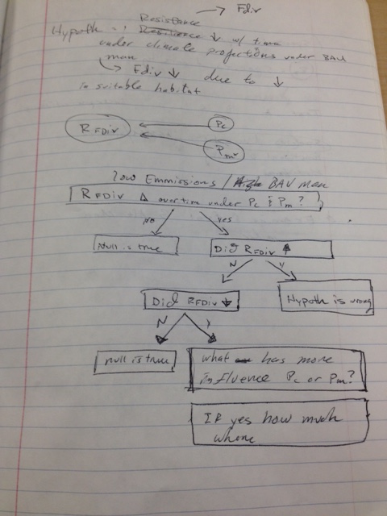

This Logic Tree explores the potential causal relationships between variables as they relate to a hypothesis (shown at the top of the image).

### Look-up-table & Mock Data

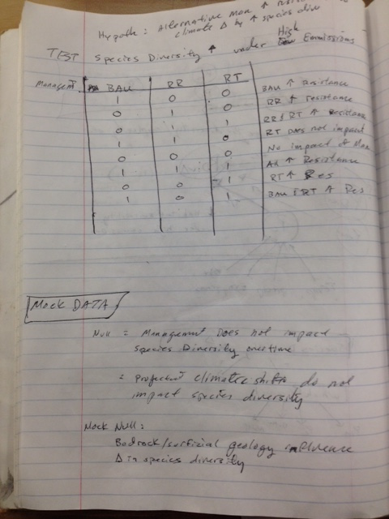

This image shows a *look-up-table* testing three predicting variables related to management. BAU, RR, and RT are three different management approaches which would be applied to the labdscape simulation.

The *mock data* explores the potential of the null hypothesis and describes an additional variable that might be at play (Bedrock and surficial geology as the main predictor/driver of species diversity change over time).

Back to Home